# R Basic-DataStructure

NingChen

# WhyR

## R?

- 1976 貝爾實驗室John Chambers,Rick Becker,Allan Wilks研發S語言
- 1993 Ross Ihaka and Robert Gentlemen,University of Auckland, New Zealand 研發R語言
- R語言是一種基於S語言所發展出具備統計分析,繪圖與資料視覺化的程式語言
- 1997 R的核心開發團隊(R development core team)成立,專責R原始碼的修改與編寫

[Companies Using R](http://www.revolutionanalytics.com/companies-using-r)

[figure not shown]

- 你沒看錯，今天其實是投資說明會，教你買地!
- 等等我們會用 R 來根據資料分析一下，看看怎樣的地才是好地 (地價高) 呢?
- R 有很多套件，裡面會有很多內建的資料集可以使用。
- 這次我們要使用的是 `MASS` 這個套件中的 `Boston` 資料集。

```r
library(MASS)
#介紹引入套件
data(Boston)
```

### 看看有甚資料

- `head` 會列出“頭” 6 筆資料。

[Show]

```r
head(Boston)
```

```
##      crim zn indus chas   nox    rm  age    dis rad tax ptratio  black
## 1 0.00632 18  2.31    0 0.538 6.575 65.2 4.0900   1 296    15.3 396.90
## 2 0.02731  0  7.07    0 0.469 6.421 78.9 4.9671   2 242    17.8 396.90
## 3 0.02729  0  7.07    0 0.469 7.185 61.1 4.9671   2 242    17.8 392.83
## 4 0.03237  0  2.18    0 0.458 6.998 45.8 6.0622   3 222    18.7 394.63
## 5 0.06905  0  2.18    0 0.458 7.147 54.2 6.0622   3 222    18.7 396.90
## 6 0.02985  0  2.18    0 0.458 6.430 58.7 6.0622   3 222    18.7 394.12
##   lstat medv
## 1  4.98 24.0
## 2  9.14 21.6
## 3  4.03 34.7
## 4  2.94 33.4
## 5  5.33 36.2
## 6  5.21 28.7
```

你也可以使用head(),Tail(),summary(),str()

## Boston Dataset有哪些Variables

| Column Name | 中文 | Column Name | 中文 |
| --- | --- | --- | --- |
| crim | 犯罪率 | dis | weighted mean of distances to five Boston employment centres距離上班商業中心地點的英哩數 |
| zn | 住宅區比例 | rad | index of accessibility to radial highways.可到最近的主要高速公路網路的便利指標 |
| indus | 工業區比例 | Tax | full-value property-tax rate per $10,000.房屋與土地相關的 Tax 比例 |
| chas | Charles River dummy variable | ptratio | pupil-teacher ratio by town 平均學生vs教師比例 |
| nox | 空氣中的一氧化氮比例(ppm)nitrogen oxides concentration (parts per 10 million). | black | 1000(Bk - 0.63)^2 where Bk is the proportion of blacks by town.非洲裔人口比例 |
| Rooms | 平均每戶的房間數目 | lstat | lower status of the population (percent).低收入戶比例 |
| age | proportion of owner-occupied units built prior to 1940.1940年前所建的自宅比例 | medv | median value of owner-occupied homes in $1000s.自有住宅房價中位數 |

## 哪些因素跟房價有相關?

```r
#解釋1非常正相關 -1是非常負相關
cor(Boston$medv,Boston)
```

```
##            crim        zn      indus      chas        nox        rm
## [1,] -0.3883046 0.3604453 -0.4837252 0.1752602 -0.4273208 0.6953599
##             age       dis        rad        tax    ptratio     black
## [1,] -0.3769546 0.2499287 -0.3816262 -0.4685359 -0.5077867 0.3334608
##           lstat medv
## [1,] -0.7376627    1
```

R也可以讓你用圖來看各欄位跟房價之間的關聯度

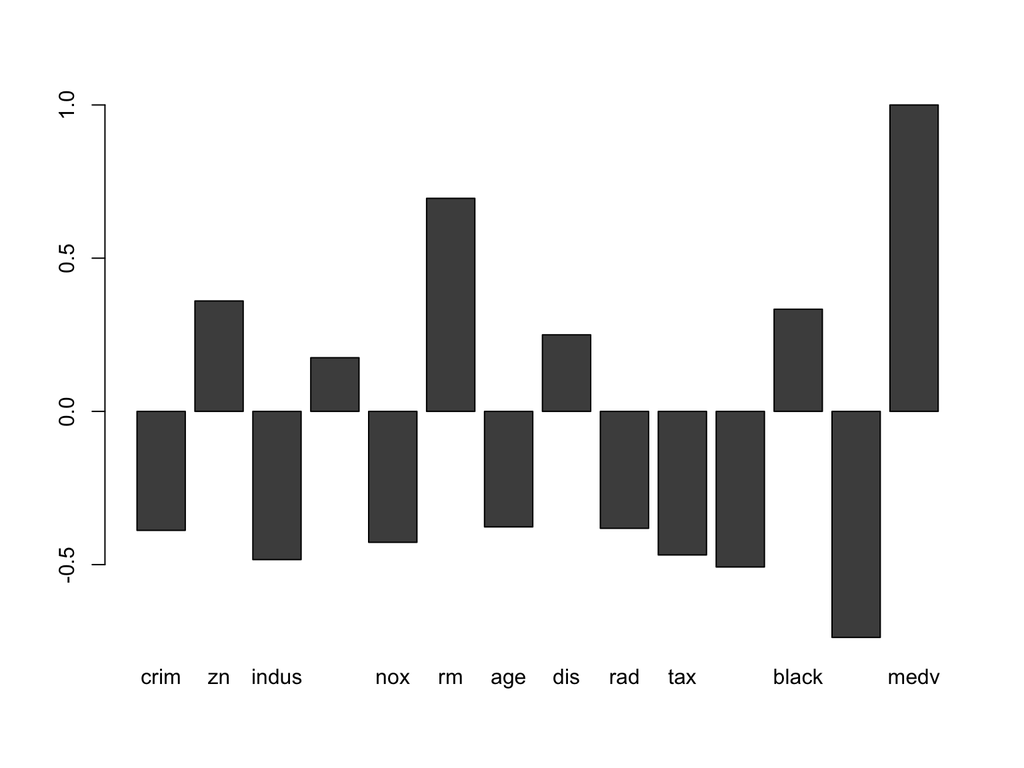

```r
barplot(cor(Boston$medv,Boston))
```

#### 我們可以知道…

房價與房間數是正相關,與低收入戶比例負相關

##### 我們再來畫畫圖看房間數跟房價關係

房間數跟房價關係

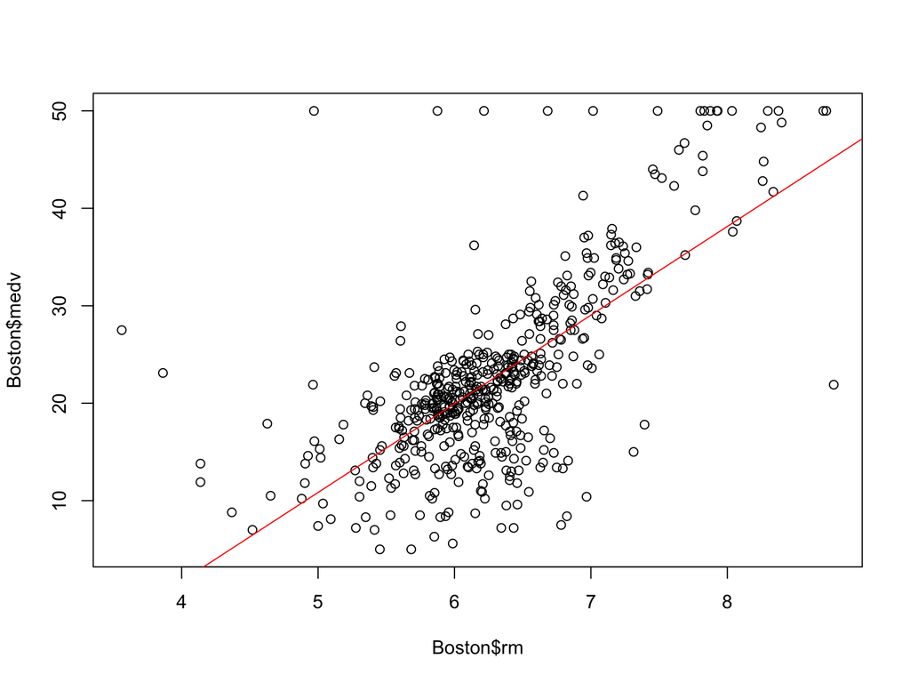

### 小練習 房間數與房價的關係

### 現在我們知道

相關性 -> 房價跟房間數正相關,低收入戶多寡負相關 (我們還畫幾張圖來看)

## 都能出國買房,買地要買就是要買最好的 最貴的

### 我要怎定義豪宅

找出前 5% (10%) 的房價

```r
quantile(Boston$medv, probs = c(0.95, 0.9))
```

```
##  95%  90%
## 43.4 34.8
```

#### 房價分布圖

- 使用 `hist` 做出房價的柱狀圖。

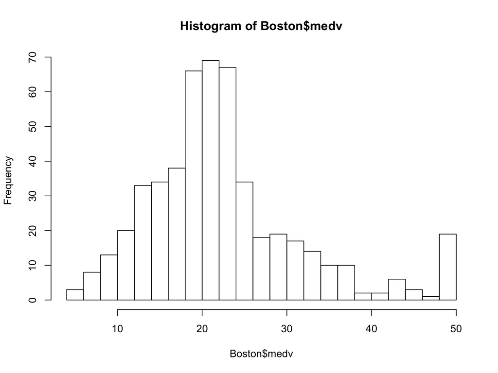

```r
hist(Boston$medv,breaks=20)
```

#### 房價分布圖

- 使用 `hist` 做出房價的柱狀圖。
- 使用 `abline` 標示出剛剛計算的前 5% 高的房價位置。

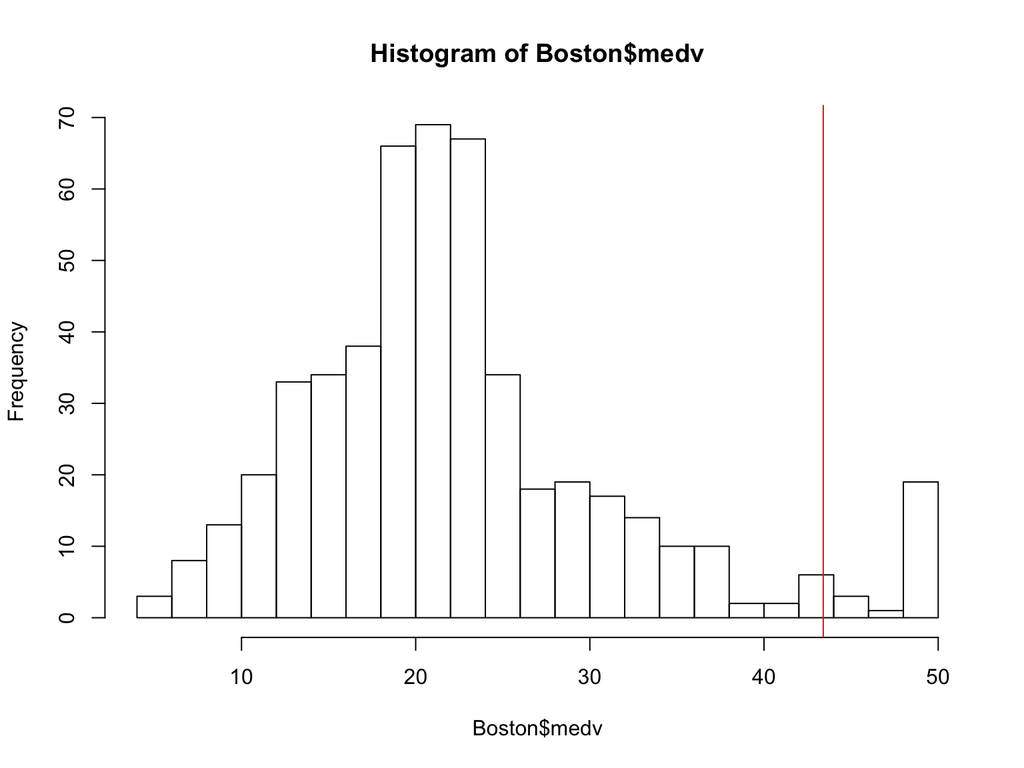

```r
hist(Boston$medv, breaks = 20)
abline(v = 43.4, col="red")
```

#### 高房價與其他是否有差異

- 前 5% 的房子的各項平均與其他房子是否有差異?
- 用 R 簡單計算來看看!

##### 平均-高房價與其他是否有差異

- 使用 `subset` 做分群。

```r
MEDVhight = subset(Boston,Boston$medv>=43.4)
MEDVOther = subset(Boston,Boston$medv< 43.4)
# MEDVhight 為房價高的資料
# MEDVOther 其他資料
```

##### 平均-高房價與其他是否有差異

- 使用 `colMeans` 計算各欄位平均。

```r
colMeans(MEDVhight)
```

```
##        crim          zn       indus        chas         nox          rm
##   1.7496015  21.9230769   8.9342308   0.2692308   0.5362692   7.6308846
##         age         dis         rad         tax     ptratio       black
##  68.0961538   3.1275077   8.5769231 356.6153846  16.1653846 383.2150000
##       lstat        medv
##   4.1546154  48.4538462
```

```r
colMeans(MEDVOther)
```

```
##         crim           zn        indus         chas          nox
##   3.71448600  10.79166667  11.25608333   0.05833333   0.55569313
##           rm          age          dis          rad          tax
##   6.21171250  68.60083333   3.83120083   9.60208333 411.03333333
##      ptratio        black        lstat         medv
##  18.57958333 355.23639583  13.11339583  21.12875000
```

- 使用 `rbind` 合併資料表。

```r
rbind(colMeans(MEDVhight),colMeans(MEDVOther))
```

```
##          crim       zn     indus       chas       nox       rm      age
## [1,] 1.749602 21.92308  8.934231 0.26923077 0.5362692 7.630885 68.09615
## [2,] 3.714486 10.79167 11.256083 0.05833333 0.5556931 6.211712 68.60083
##           dis      rad      tax  ptratio    black     lstat     medv
## [1,] 3.127508 8.576923 356.6154 16.16538 383.2150  4.154615 48.45385
## [2,] 3.831201 9.602083 411.0333 18.57958 355.2364 13.113396 21.12875
```

高房價區 犯罪率較低 工業區較少 住宅區比例高

#### 我們現在知道～～

1. 平均數 rbind->富裕區 犯罪率較低 工業區較少 住宅區比例高
2. 相關性 -> 房價跟房間數正相關,低收入戶多寡負相關

## 高房價區 低收入戶多寡分佈

我們可以嘗試將低收入戶分類

[Show]

```r
Boston2=Boston
Boston2$Income=cut(Boston2$lstat,breaks=3)
#將低收入戶比例分成三區
Boston2$Income
```

```
##   [1] (1.69,13.8] (1.69,13.8] (1.69,13.8] (1.69,13.8] (1.69,13.8]
##   [6] (1.69,13.8] (1.69,13.8] (13.8,25.9] (25.9,38]   (13.8,25.9]
##  [11] (13.8,25.9] (1.69,13.8] (13.8,25.9] (1.69,13.8] (1.69,13.8]
##  [16] (1.69,13.8] (1.69,13.8] (13.8,25.9] (1.69,13.8] (1.69,13.8]
##  [21] (13.8,25.9] (13.8,25.9] (13.8,25.9] (13.8,25.9] (13.8,25.9]
##  [26] (13.8,25.9] (13.8,25.9] (13.8,25.9] (1.69,13.8] (1.69,13.8]
##  [31] (13.8,25.9] (1.69,13.8] (25.9,38]   (13.8,25.9] (13.8,25.9]
##  [36] (1.69,13.8] (1.69,13.8] (1.69,13.8] (1.69,13.8] (1.69,13.8]
##  [41] (1.69,13.8] (1.69,13.8] (1.69,13.8] (1.69,13.8] (1.69,13.8]
##  [46] (1.69,13.8] (13.8,25.9] (13.8,25.9] (25.9,38]   (13.8,25.9]
##  [51] (1.69,13.8] (1.69,13.8] (1.69,13.8] (1.69,13.8] (13.8,25.9]
##  [56] (1.69,13.8] (1.69,13.8] (1.69,13.8] (1.69,13.8] (1.69,13.8]
##  [61] (1.69,13.8] (13.8,25.9] (1.69,13.8] (1.69,13.8] (1.69,13.8]
##  [66] (1.69,13.8] (1.69,13.8] (1.69,13.8] (1.69,13.8] (1.69,13.8]
##  [71] (1.69,13.8] (1.69,13.8] (1.69,13.8] (1.69,13.8] (1.69,13.8]
```

[output cut: 88 more lines]

也許用文字來看更清楚

[Show]

```r
Boston2$Income= cut(Boston2$lstat,breaks=3,labels=c("H","M","L"))
MEDVhight2 = subset(Boston2,Boston$medv>=43.4)
MEDVhight2$Income
```

```
##  [1] H H H H H H H H H H H H H H H H H H H H H H H H H H
## Levels: H M L
```

我可以計算有多少“H”嗎?

[Show]

```r
table(MEDVhight2$Income)
```

```
##
##  H  M  L
## 26  0  0
```

## Recape

- 平均數 rbind->富裕區 犯罪率較低 工業區較少 住宅區比例高
- 相關性 -> 房價跟房間數正相關,低收入戶多寡負相關

take a rest

## 我們來回顧剛剛研究的dataset

```r
str(Boston2)
```

```
## 'data.frame':    506 obs. of  15 variables:
##  $ crim   : num  0.00632 0.02731 0.02729 0.03237 0.06905 ...
##  $ zn     : num  18 0 0 0 0 0 12.5 12.5 12.5 12.5 ...
##  $ indus  : num  2.31 7.07 7.07 2.18 2.18 2.18 7.87 7.87 7.87 7.87 ...
##  $ chas   : int  0 0 0 0 0 0 0 0 0 0 ...
##  $ nox    : num  0.538 0.469 0.469 0.458 0.458 0.458 0.524 0.524 0.524 0.524 ...
##  $ rm     : num  6.58 6.42 7.18 7 7.15 ...
##  $ age    : num  65.2 78.9 61.1 45.8 54.2 58.7 66.6 96.1 100 85.9 ...
##  $ dis    : num  4.09 4.97 4.97 6.06 6.06 ...
##  $ rad    : int  1 2 2 3 3 3 5 5 5 5 ...
##  $ tax    : num  296 242 242 222 222 222 311 311 311 311 ...
##  $ ptratio: num  15.3 17.8 17.8 18.7 18.7 18.7 15.2 15.2 15.2 15.2 ...
##  $ black  : num  397 397 393 395 397 ...
##  $ lstat  : num  4.98 9.14 4.03 2.94 5.33 ...
##  $ medv   : num  24 21.6 34.7 33.4 36.2 28.7 22.9 27.1 16.5 18.9 ...
##  $ Income : Factor w/ 3 levels "H","M","L": 1 1 1 1 1 1 1 2 3 2 ...
```

# 我們所分析的數據代表什麼意義？

## 先來介紹 Vector 向量

try

```r
x=1
```

how to input more than length=1 ?

x=1,2

Failed? Why?

我要輸入12月份

```r
Month1=c(1,2,3,4,5,6,7,8,9,10,11,12)
length(Month1)
```

```
## [1] 12
```

```r
Month2=1:12
length(Month2)
```

```
## [1] 12
```

## 練習一下

台北恆春每月平均溫度

| 月份 | 1 | 2 | 3 | 4 | 5 | 6 | 7 | 8 | 9 | 10 | 11 | 12 |
| --- | --- | --- | --- | --- | --- | --- | --- | --- | --- | --- | --- | --- |
| 台北 | 16.1 | 16.5 | 18.5 | 21.9 | 25.2 | 27.7 | 29.6 | 29.2 | 27.4 | 24.5 | 21.5 | 17.9 |
| 恆春 | 20.7 | 21.4 | 23.2 | 25.2 | 27.0 | 27.9 | 28.4 | 28.1 | 27.4 | 26.3 | 24.3 | 21.7 |

```r
TaipeiTem=c(16.1,16.5,18.5 ,    21.9 ,  25.2 ,  27.7 ,  29.6 ,  29.2,27.4,24.5 ,    21.5 ,  17.9)
HengchunTem=c(20.7 , 21.4 , 23.2 ,  25.2 ,  27.0 ,  27.9 ,  28.4 ,  28.1 ,  27.4 ,  26.3 ,  24.3 ,  21.7)
```

加上月份

```r
names(TaipeiTem)=Month1
names(HengchunTem)=Month2
```

```r
1:3
```

```
## [1] 1 2 3
```

```r
c(1, 2, 3) + 1
```

```
## [1] 2 3 4
```

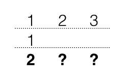

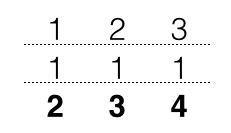

## 練習看看

```r
1:3 * 2
```

```
## [1] 2 4 6
```

### 向量有同質性 Vector

Character > Numeric > Integer > Logical

```r
x <- c(1L, 2.0, "3")
class(x)
x
```

[output not shown]

- 改一個，全部就都變了

## 統計上資料測量的尺度

統計上資料測量的尺度

- 名目資料(nomial)
- 順序資料(ordinal)
- 區間資料(interval)
- 比例資料(ratio)

| “資料衡量尺度” | “變數形態” | “特性” |  |
| --- | --- | --- | --- |
| 1 | “名目資料” | “質化” | “類別” |
| 2 | “順序資料” | “質化” | “優先順序” |
| 3 | “區間資料” | “量化” | “大小距離” |
| 4 | “比例資料” | “量化” | “比值” |

### 名目資料

數值只用於記號，“值”毫無意義的數據

- 性別
- 國家/班級

| 男 | 女 |
| --- | --- |
| 0 | 1 |

| 男 | 女 |
| --- | --- |
| 1 | 2 |

### 順序資料

數值有順序關係，但是差距沒有意義  
- 名次  
- 排序表  
第一名的成績一定比第二名好,但不代表第一名比第二名好兩倍

### 區間資料

有差距的概念，沒有倍數的概念。  
數值有1的概念，沒有0的概念。可加減。  
- 溫度  
- 時間

### 比值資料

同時有差距和倍數的概念。 可加減乘除。

- 使用者人數
- 營收

## R 的資料形態分類

### Character

- 最廣泛的資料結構，可用於處理文字相關的工作，如：設定圖片的標題
- 輸入的時候利用`"`或`'`來包覆要輸入的文字

### 常用的Character處理函數

字串的剪接：`paste

```r
x <- "abc";y <- "dbbbe"
paste(x, y, sep=",")
```

```
## [1] "abc,dbbbe"
```

字串的切割：`strsplit`

```r
strsplit(x, "b")
```

```
## [[1]]
## [1] "a" "c"
```

截取子字串：`substring`

```r
name1<-"郭雪芙"
substring(name1, 1, 1)
```

```
## [1] "郭"
```

練習一下 取出金城武的姓

```r
name2<-"金城武"
substring(name2, 1, 2)
```

```
## [1] "金城"
```

### Factor(常用於處理質性變數)

如何處理名目變數?

```r
x <- c("F","M","F","F")
x
```

```
## [1] "F" "M" "F" "F"
```

```r
x <- factor(c("F","M","F","F"), levels=c("F","M"))
x
```

```
## [1] F M F F
## Levels: F M
```

```r
x <- factor(c("F","M","F","F"), levels=c("F"))
levels(x)
```

```
## [1] "F"
```

```r
as.integer(x)
```

```
## [1]  1 NA  1  1
```

### 如何處理順序資料?

```r
#農業社會 男尊女卑
Argri <- factor(c("F","M","F","F"),order=TRUE,levels=c("F","M"))

#阿美族 女尊男卑
Amis <- factor(c("F","M","F","F"),order=FALSE,levels=c("F","M"))

#應該要用
Amis <- factor(c("F","M","F","F"),order=TRUE,levels=c("M","F"))
```

```r
#舉一個認真的例子 - 班上一號到六號分別拿到A,B,C的級別
rank=factor(c("C","A","B","B","C","C"),order=TRUE,level=c("C","B","A"))
rank
```

```
## [1] C A B B C C
## Levels: C < B < A
```

```r
rank[1]<rank[2]
```

```
## [1] TRUE
```

### 量性 Integer and Numeric

`+`

```r
1 + 2
```

```
## [1] 3
```

`-`

```r
1 - 2
```

```
## [1] -1
```

`*`

```r
1 * 2
```

```
## [1] 2
```

`/`

```r
1L / 2L
```

```
## [1] 0.5
```

### 判斷 Logical

產生自比較，或是使用`T`、`TRUE`、`F`或`FALSE`輸入

```r
x <- 1
x < 2
```

```
## [1] TRUE
```

```r
x <= 1
```

```
## [1] TRUE
```

Recape

| “資料衡量尺度” | “變數形態” | “特性” |  |
| --- | --- | --- | --- |
| 1 | “名目資料” | “質化” | “類別” |
| 2 | “順序資料” | “質化” | “優先順序” |
| 3 | “區間資料” | “量化” | “大小距離” |
| 4 | “比例資料” | “量化” | “比值” |

## R 的資料結構

### Vector 向量式資料結構

### 異質性資料 List

```r
x<-list(1L,2,"3")
```

*連函數都吃

```r
x<-list(1L,2,"3",mean)
```

### 異質性資料 dataframe

View(Boston) str(Boston)

#### Ways to add a column

Boston$Income<-  
Boston[[“Income”]]<-

#### Ways to remove the column

Boston$Income<-NULL Boston[[“Income”]]<-NULL

#### subset

rbind

```r
Serial=c(1,2,3)
RBasicTeacher=c("Dboy", "Ning", "Noha")
RBasicRbind=rbind(Serial,RBasicTeacher)
```

cbind

```r
Serial=c(1,2,3)
RBasicTeacher=c("Dboy", "Ning", "Noha")
RBasicCbind=cbind(Serial,RBasicTeacher)
RBasic=cbind(c(1,2,3),c("Dboy", "Ning", "Noha"))
```

### Merge

```r
PageView <- read.table(header=TRUE, text='
     Date       PageView Rating
           7/1      1231     6.7
           7/2      5423    4.5
           7/3      3219    3.7
           7/4       998    3.3
           7/5       3241    4.1
           7/6       1223    5.2')
Promotion <- read.table(header=TRUE, text='
     Date       Promotion
           7/1      N
           7/2      Y
           7/3      Y
           7/4      N
           7/5      Y
           7/6      N   ')

merge(PageView,Promotion,"Date")
```

```
##   Date PageView Rating Promotion
## 1  7/1     1231    6.7         N
## 2  7/2     5423    4.5         Y
## 3  7/3     3219    3.7         Y
## 4  7/4      998    3.3         N
## 5  7/5     3241    4.1         Y
## 6  7/6     1223    5.2         N
```

### 轉換資料結構

`as`

- `as.character`
- `as.logical`
- `as.integer`
- `as.numeric`

```r
as.numeric("2")
```

```
## [1] 2
```

```r
as.integer("a")
```

```
## [1] NA
```

```r
x <- c(1, 2, 3, 2, 3, 2, 1)
as.character(x) # 字串
```

```
## [1] "1" "2" "3" "2" "3" "2" "1"
```

```r
factor(x) # ??用剛才dataframe作
```

```
## [1] 1 2 3 2 3 2 1
## Levels: 1 2 3
```

### 直接轉換

```r
x <- c("1", "2", "3", "2", "a")
as.numeric(x)
```

```
## [1]  1  2  3  2 NA
```

- `NA`代表Not available，代表著**missing value**

## 資料形態的轉換 - 資料清理

### 民國80年至82年的國民生產毛額

百萬元 5,023,763 5,614,679 6,205,338

```r
gdp <- c("5,023,763", "5,614,679", "6,205,338")
as.numeric(gsub(",", "", gdp))
```

```
## [1] 5023763 5614679 6205338
```

## summary 指令

- 根據資料形態的不同，函數的輸出結果也會不同

### Factor

```r
factor_example=factor(c("三年甲班", "三年乙班", "三年甲班"))
summary(factor_example)
```

```
## 三年乙班 三年甲班
##        1        2
```

三年乙班 三年甲班 1 2

### Character

```r
character_example=c("a","b","c")
summary(character_example)
```

```
##    Length     Class      Mode
##         3 character character
```

Length Class Mode 3 character character

### List

```r
list_example <- list(1L, 2.0, "3")
summary(list_example)
```

```
##      Length Class  Mode
## [1,] 1      -none- numeric
## [2,] 1      -none- numeric
## [3,] 1      -none- character
```

Length Class Mode  
[1,] 1 -none- numeric  
[2,] 1 -none- numeric  
[3,] 1 -none- character

### DataFreame

```r
summary(Boston)
```

```
##       crim                zn             indus            chas
##  Min.   : 0.00632   Min.   :  0.00   Min.   : 0.46   Min.   :0.00000
##  1st Qu.: 0.08204   1st Qu.:  0.00   1st Qu.: 5.19   1st Qu.:0.00000
##  Median : 0.25651   Median :  0.00   Median : 9.69   Median :0.00000
##  Mean   : 3.61352   Mean   : 11.36   Mean   :11.14   Mean   :0.06917
##  3rd Qu.: 3.67708   3rd Qu.: 12.50   3rd Qu.:18.10   3rd Qu.:0.00000
##  Max.   :88.97620   Max.   :100.00   Max.   :27.74   Max.   :1.00000
##       nox               rm             age              dis
##  Min.   :0.3850   Min.   :3.561   Min.   :  2.90   Min.   : 1.130
##  1st Qu.:0.4490   1st Qu.:5.886   1st Qu.: 45.02   1st Qu.: 2.100
##  Median :0.5380   Median :6.208   Median : 77.50   Median : 3.207
##  Mean   :0.5547   Mean   :6.285   Mean   : 68.57   Mean   : 3.795
##  3rd Qu.:0.6240   3rd Qu.:6.623   3rd Qu.: 94.08   3rd Qu.: 5.188
##  Max.   :0.8710   Max.   :8.780   Max.   :100.00   Max.   :12.127
##       rad              tax           ptratio          black
##  Min.   : 1.000   Min.   :187.0   Min.   :12.60   Min.   :  0.32
##  1st Qu.: 4.000   1st Qu.:279.0   1st Qu.:17.40   1st Qu.:375.38
##  Median : 5.000   Median :330.0   Median :19.05   Median :391.44
##  Mean   : 9.549   Mean   :408.2   Mean   :18.46   Mean   :356.67
##  3rd Qu.:24.000   3rd Qu.:666.0   3rd Qu.:20.20   3rd Qu.:396.23
##  Max.   :24.000   Max.   :711.0   Max.   :22.00   Max.   :396.90
##      lstat            medv
##  Min.   : 1.73   Min.   : 5.00
##  1st Qu.: 6.95   1st Qu.:17.02
##  Median :11.36   Median :21.20
##  Mean   :12.65   Mean   :22.53
##  3rd Qu.:16.95   3rd Qu.:25.00
##  Max.   :37.97   Max.   :50.00
```

## 資料的選取

### 向量的選取

#### 坐標

```r
x <- 1:5
x[2:3]
```

```
## [1] 2 3
```

### 布林

```r
x <- 1:5
x > 3
```

```
## [1] FALSE FALSE FALSE  TRUE  TRUE
```

```r
x[x > 3]
```

```
## [1] 4 5
```

## 小挑戰選取台北恆春天氣資料

```r
# 先印出台北跟恆春每個月平均溫度
TaipeiTem
```

```
##    1    2    3    4    5    6    7    8    9   10   11   12
## 16.1 16.5 18.5 21.9 25.2 27.7 29.6 29.2 27.4 24.5 21.5 17.9
```

```r
HengchunTem
```

```
##    1    2    3    4    5    6    7    8    9   10   11   12
## 20.7 21.4 23.2 25.2 27.0 27.9 28.4 28.1 27.4 26.3 24.3 21.7
```

# 分別選取出兩地溫度>20度的月份

- “> <”

```r
TaipeiTem>20
```

```
##     1     2     3     4     5     6     7     8     9    10    11    12
## FALSE FALSE FALSE  TRUE  TRUE  TRUE  TRUE  TRUE  TRUE  TRUE  TRUE FALSE
```

```r
TaipeiHotMonths = TaipeiTem[TaipeiTem>20]
```

- True & False

```r
SelectMonth= HengchunTem>20
HengchunHotMonths = HengchunTem[SelectMonth==TRUE]
```

- 找出夏天(七八九月)平均溫度

  ```r
   TaipeiTem[7:9]
  ```

  ```
  ##    7    8    9
  ## 29.6 29.2 27.4
  ```

  ```r
  mean(TaipeiTem[7:9])
  ```

  ```
  ## [1] 28.73333
  ```

  ```r
  HengchunTem[7:9]
  ```

  ```
  ##    7    8    9
  ## 28.4 28.1 27.4
  ```

  ```r
  mean(HengchunTem[7:9])
  ```

  ```
  ## [1] 27.96667
  ```

- 找出冬天(十二,一,二月)平均溫度

```r
# TaipeiTem[1,2,12]

mean(TaipeiTem[c(1,2,12)])
```

```
## [1] 16.83333
```

```r
mean(HengchunTem[c(1,2,12)])
```

```
## [1] 21.26667
```

## 表格的選取

```r
TemTable=rbind(TaipeiTem,HengchunTem)
TemTable
```

```
##                1    2    3    4    5    6    7    8    9   10   11   12
## TaipeiTem   16.1 16.5 18.5 21.9 25.2 27.7 29.6 29.2 27.4 24.5 21.5 17.9
## HengchunTem 20.7 21.4 23.2 25.2 27.0 27.9 28.4 28.1 27.4 26.3 24.3 21.7
```

```r
#選取台北二月的溫度
TemTable[1,2]
```

```
## [1] 16.5
```

```r
#選取二月的溫度
TemTable[,2]
```

```
##   TaipeiTem HengchunTem
##        16.5        21.4
```

```r
TemTable[1,]
```

```
##    1    2    3    4    5    6    7    8    9   10   11   12
## 16.1 16.5 18.5 21.9 25.2 27.7 29.6 29.2 27.4 24.5 21.5 17.9
```

## 欄的選取

```r
head(Boston)
```

```
##      crim zn indus chas   nox    rm  age    dis rad tax ptratio  black
## 1 0.00632 18  2.31    0 0.538 6.575 65.2 4.0900   1 296    15.3 396.90
## 2 0.02731  0  7.07    0 0.469 6.421 78.9 4.9671   2 242    17.8 396.90
## 3 0.02729  0  7.07    0 0.469 7.185 61.1 4.9671   2 242    17.8 392.83
## 4 0.03237  0  2.18    0 0.458 6.998 45.8 6.0622   3 222    18.7 394.63
## 5 0.06905  0  2.18    0 0.458 7.147 54.2 6.0622   3 222    18.7 396.90
## 6 0.02985  0  2.18    0 0.458 6.430 58.7 6.0622   3 222    18.7 394.12
##   lstat medv
## 1  4.98 24.0
## 2  9.14 21.6
## 3  4.03 34.7
## 4  2.94 33.4
## 5  5.33 36.2
## 6  5.21 28.7
```

```r
head(Boston[["crim"]]) # head(Boston$crim)
```

```
## [1] 0.00632 0.02731 0.02729 0.03237 0.06905 0.02985
```

## 探索一個變數

### 量化數據

- 敘述統計量：`mean`、`sd`、`median`、`quantile`

### 質化數據

- 分佈表格：`table`

# 補充資料

- Swirls
- Introduction to R(around 4 hours)  
  https://www.datacamp.com/courses/free-introduction-to-r
- Cookbook for R

# Acknowlege

DBoy,Wush,智程